# Indel Signature InsDel5a

# InsDel5a

(corresponds to 83-type signature C_ID5)

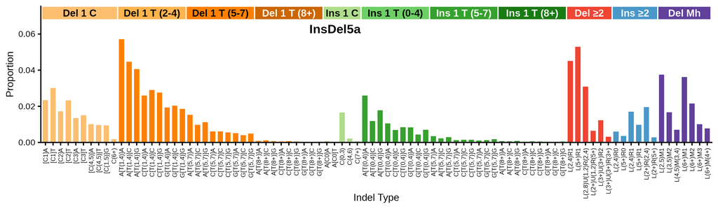

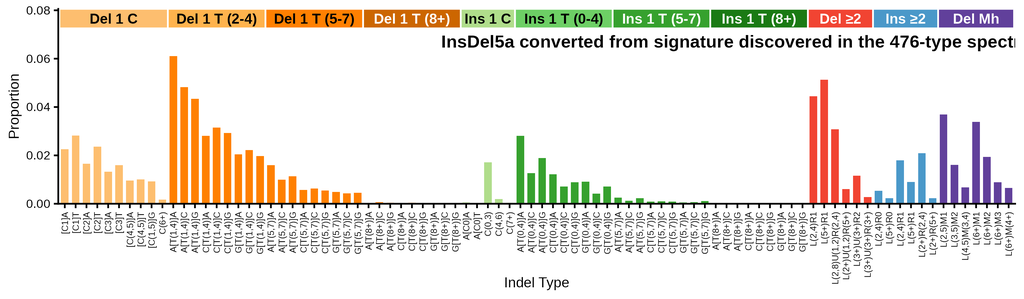

89-type spectrum of the linking tumor SP97194 | cosine similarity to InsDel5a: 0.9908

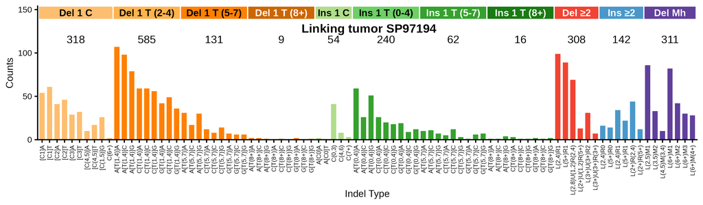

**Click to view decomposition of the linking tumor spectrum**

Partial mutation signature of SP97194 due to InsDel5a

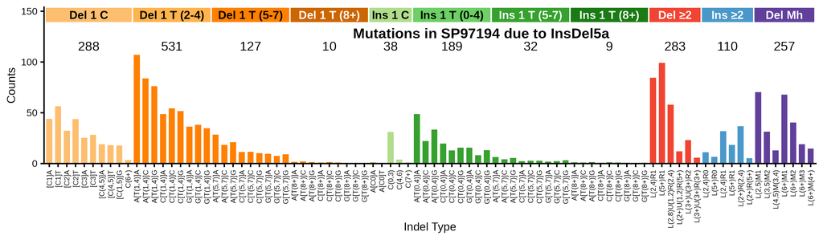

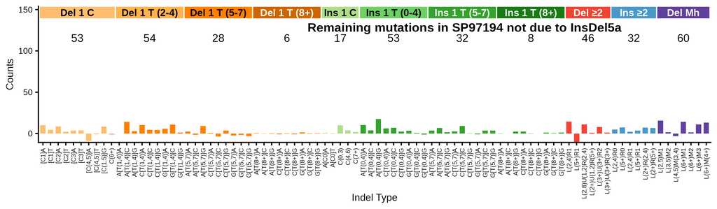

Max neg fraction (maximum allowed negative residual count as fraction of total): 0.02  
N subtract (mutation count assigned to signature): 1874.8  
N residual (mutation count in residual “partial spectrum”): 301.2  
Total negative (sum of negative residual mutation counts): 43.5  
N negative channels (number of channels with negative residual): 24  
P(≥ total negative) (Monte Carlo estimated probability that negative-binomial-sampled spectra from the signature contributing N subtract mutations would produce a total negative count >= the observed Total negative; higher number means not surprising): 1.000

**Per-channel residual breakdown**

| Channel | Spectrum | Sig_Count | Residual | Sig_Prop |
| --- | --- | --- | --- | --- |
| [Del(C):R1]A | 54 | 43.9 | 10.1 | 0.02343 |
| [Del(C):R1]T | 61 | 56.5 | 4.5 | 0.03014 |
| [Del(C):R2]A | 41 | 32.4 | 8.6 | 0.01728 |
| [Del(C):R2]T | 46 | 43.8 | 2.2 | 0.02334 |
| [Del(C):R3]A | 29 | 25.3 | 3.7 | 0.01352 |
| [Del(C):R3]T | 32 | 28.2 | 3.8 | 0.01505 |
| [Del(C):R(4,5)]A | 10 | 18.9 | -8.9 | 0.01010 |
| [Del(C):R(4,5)]T | 17 | 18.0 | -1 | 0.00963 |
| [Del(C):R(1,5)]G | 26 | 17.7 | 8.3 | 0.00944 |
| Del(C):R(6,9) | 2 | 3.5 | -1.5 | 0.00187 |
| A[Del(T):R(1,4)]A | 107 | 107.1 | -0.1 | 0.05713 |
| A[Del(T):R(1,4)]C | 98 | 83.9 | 14.1 | 0.04474 |
| A[Del(T):R(1,4)]G | 79 | 76.1 | 2.9 | 0.04060 |
| C[Del(T):R(1,4)]A | 59 | 48.7 | 10.3 | 0.02597 |
| C[Del(T):R(1,4)]C | 59 | 54.4 | 4.6 | 0.02904 |
| C[Del(T):R(1,4)]G | 56 | 51.7 | 4.3 | 0.02756 |
| G[Del(T):R(1,4)]A | 42 | 36.3 | 5.7 | 0.01934 |
| G[Del(T):R(1,4)]C | 49 | 38.2 | 10.8 | 0.02036 |
| G[Del(T):R(1,4)]G | 36 | 34.8 | 1.2 | 0.01857 |
| A[Del(T):R(5,7)]A | 31 | 28.6 | 2.4 | 0.01525 |
| A[Del(T):R(5,7)]C | 17 | 18.4 | -1.4 | 0.00980 |
| A[Del(T):R(5,7)]G | 30 | 21.0 | 9 | 0.01119 |
| C[Del(T):R(5,7)]A | 12 | 11.4 | 0.6 | 0.00607 |
| C[Del(T):R(5,7)]C | 8 | 11.5 | -3.5 | 0.00615 |
| C[Del(T):R(5,7)]G | 14 | 10.3 | 3.7 | 0.00551 |
| G[Del(T):R(5,7)]A | 7 | 9.5 | -2.5 | 0.00509 |
| G[Del(T):R(5,7)]C | 6 | 7.6 | -1.6 | 0.00407 |
| G[Del(T):R(5,7)]G | 6 | 9.1 | -3.1 | 0.00487 |
| A[Del(T):R(8,)]A | 2 | 1.6 | 0.4 | 0.00088 |
| A[Del(T):R(8,)]C | 2 | 2.2 | -0.2 | 0.00116 |

[output cut: 59 more lines]

**Click to view similar signatures from Koh et al.**

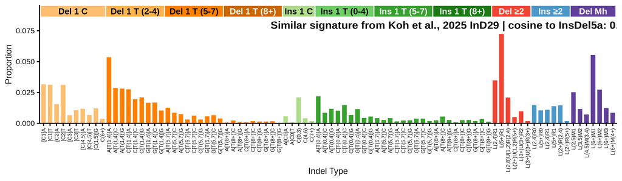

## 476-type representations corresponding to InsDel5a

Extracted 476-type signature corresponding to InsDel5a

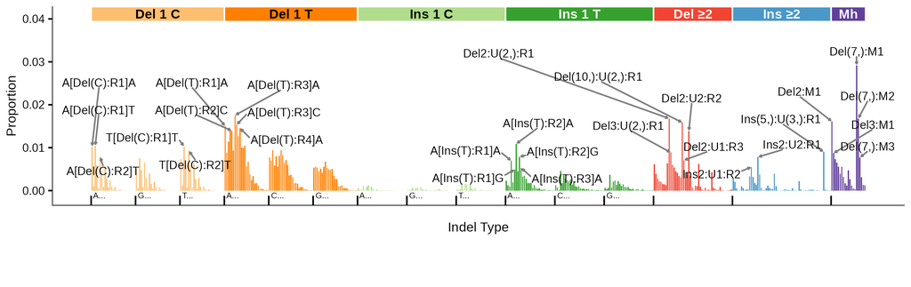

476-type spectrum of the linking tumor SP97194; cosine similarity to the extracted 476-type signature is 0.9718

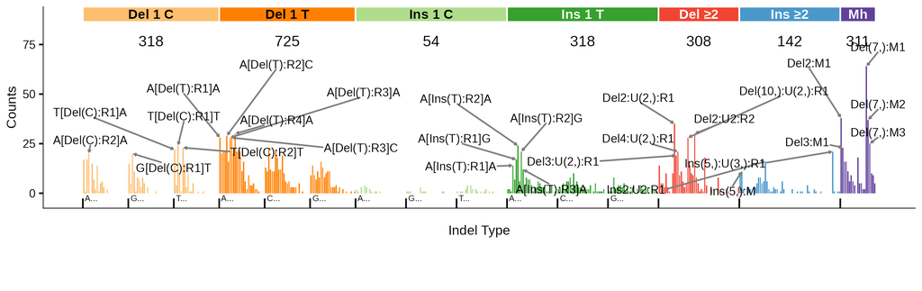

## 83-type signature corresponding to InsDel5a (C_ID5)

**Note**

WARNING: The 83-type signature C_ID5 corresponds to both InsDel5a and InsDel5b. The C_ID5 extraction mainly excluded T deletions in long poly-T contexts that were detected in InsDel5b in extractions in the 89-type and 476-type classification, but not in the InsDel5a extractions. Thus, C_ID5 corresponds more closely to InsDel5a than to InsDel5b

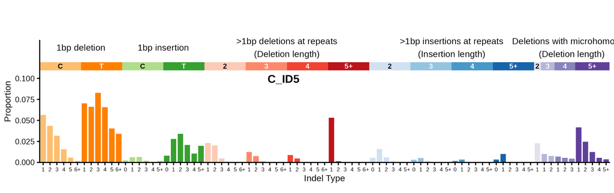

83-type signature converted from signature discovered in the 476-type spectra (using bipartite matching optimization) | cosine similarity to C_ID5: 0.9977

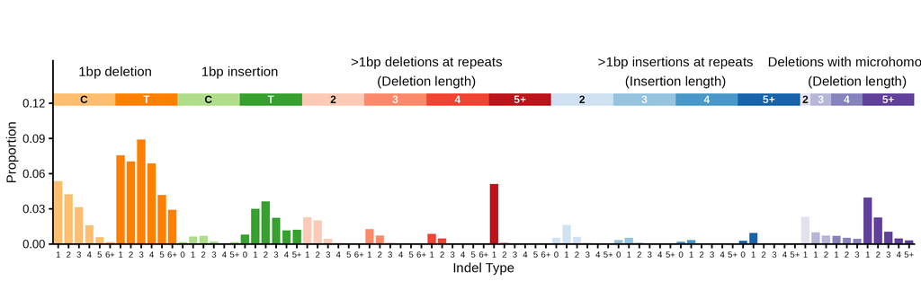

**Click to see flow diagrams: 476-type to 83-type collapse**

These Sankey diagrams show how the 476-type mutation categories are redistributed to 83-type categories using bipartite matching. We only show the diagrams for insertions or deletions of > 1 base because it is for these indels that 476-type categories map to > 1 83-type category.

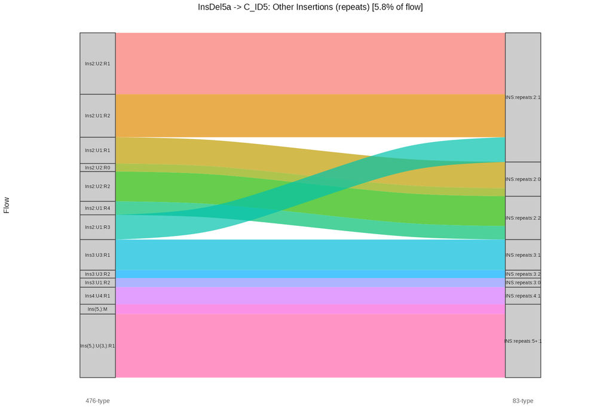

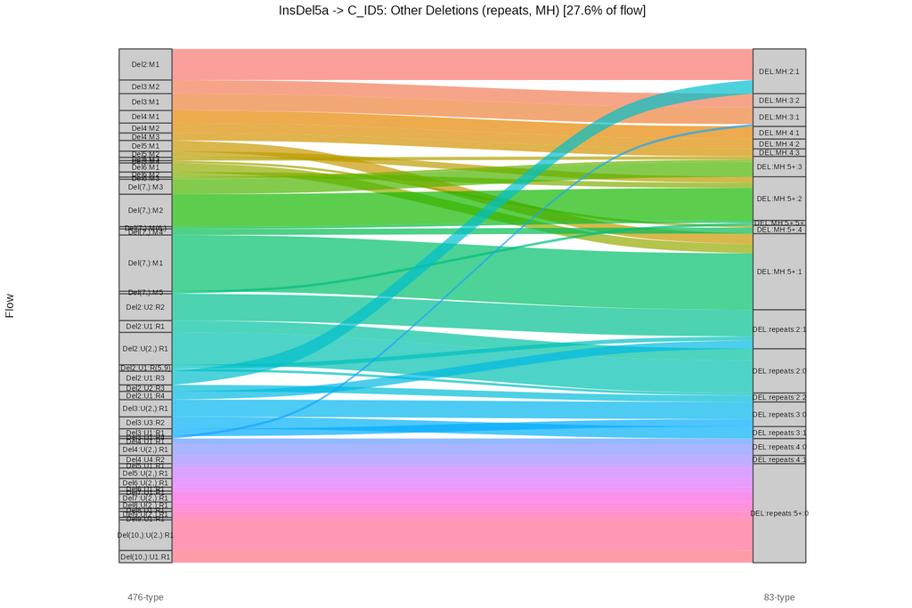

83-type spectrum of the linking tumor SP97194 | cosine similarity to C_ID5: 0.991

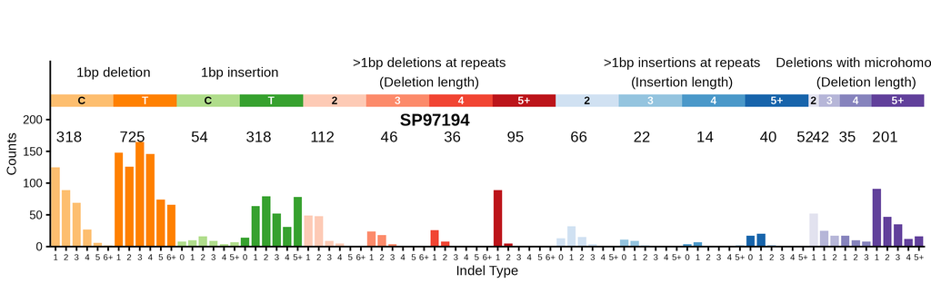

83-type spectrum of best 83-type matching tumor SP102755 | cosine similarity to C_ID5: 0.9948

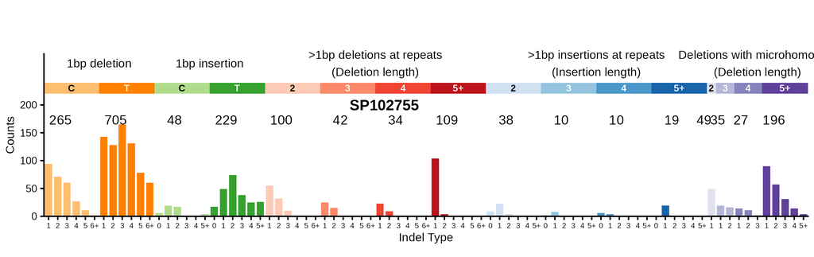

### Similar COSMIC signatures

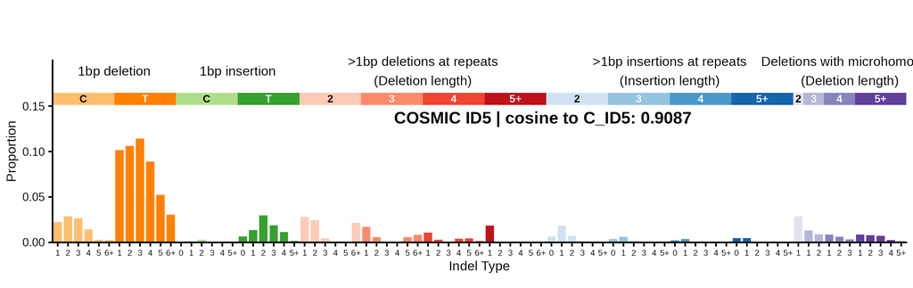